# Homework 4: Machine Learning

Eugene Nesterenko, github YevheniiN281

2023-06-01

# 1 The Bechdel Test

https://fivethirtyeight.com/features/the-dollar-and-cents-case-against-hollywoods-exclusion-of-women/

The [Bechdel test](https://bechdeltest.com) is a way to assess how women are depicted in Hollywood movies. In order for a movie to pass the test:

1. It has to have at least two [named] women in it
2. Who talk to each other
3. About something besides a man

There is a nice article and analysis you can find here https://fivethirtyeight.com/features/the-dollar-and-cents-case-against-hollywoods-exclusion-of-women/ We have a sample of 1394 movies and we want to fit a model to predict whether a film passes the test or not.

```r
bechdel <- read_csv(here::here("data", "bechdel.csv")) %>%
  mutate(test = factor(test))
glimpse(bechdel)
```

```
## Rows: 1,394
## Columns: 10
## $ year          <dbl> 2013, 2013, 2013, 2013, 2013, 2013, 2013, 2013, 2013, 20…
## $ title         <chr> "12 Years a Slave", "2 Guns", "42", "47 Ronin", "A Good …
## $ test          <fct> Fail, Fail, Fail, Fail, Fail, Pass, Pass, Fail, Pass, Pa…
## $ budget_2013   <dbl> 2.00, 6.10, 4.00, 22.50, 9.20, 1.20, 1.30, 13.00, 4.00, …
## $ domgross_2013 <dbl> 5.3107035, 7.5612460, 9.5020213, 3.8362475, 6.7349198, 1…
## $ intgross_2013 <dbl> 15.8607035, 13.2493015, 9.5020213, 14.5803842, 30.424919…
## $ rated         <chr> "R", "R", "PG-13", "PG-13", "R", "R", "PG-13", "PG-13", …
## $ metascore     <dbl> 97, 55, 62, 29, 28, 55, 48, 33, 90, 58, 52, 78, 83, 53, …
## $ imdb_rating   <dbl> 8.3, 6.8, 7.6, 6.6, 5.4, 7.8, 5.7, 5.0, 7.5, 7.4, 6.2, 7…
## $ genre         <chr> "Biography", "Action", "Biography", "Action", "Action", …
```

How many films fail/pass the test, both as a number and as a %?

```r
# Grouping the data by pass/fail criterion, counting occurances and percantage of each
bechdel %>%
  group_by(test) %>%
  summarize(count = n()) %>%
  mutate(percentage = round(count/sum(count)*100,1)) %>%
  print()
```

```
## # A tibble: 2 × 3
##   test  count percentage
##   <fct> <int>      <dbl>
## 1 Fail    772       55.4
## 2 Pass    622       44.6
```

772 movies (55.4%) **fail** the Bechdel test, while only 622 (44.6%) **pass** it

## 1.1 Movie scores

[figure not shown]

```r
ggplot(data = bechdel, aes(
  x = metascore,
  y = imdb_rating,
  colour = test
)) +
  geom_point(alpha = .3, size = 3) +
  scale_colour_manual(values = c("tomato", "olivedrab")) +
  labs(
    x = "Metacritic score",
    y = "IMDB rating",
    colour = "Bechdel test"
  ) +
 theme_light()
```

# 2 Split the data

```r
# **Split the data**

set.seed(123)

data_split <- initial_split(bechdel, # updated data
                           prop = 0.8,
                           strata = test)

bechdel_train <- training(data_split)
bechdel_test <- testing(data_split)
```

Check the counts and % (proportions) of the `test` variable in each set.

```r
# Grouping the data by pass/fail criterion, counting occurances and percantage of each
# Apply separately to training sample
bechdel_train %>%
  group_by(test) %>%
  summarize(count = n()) %>%
  mutate(percentage = round(count/sum(count)*100,1)) %>%
  print()
```

```
## # A tibble: 2 × 3
##   test  count percentage
##   <fct> <int>      <dbl>
## 1 Fail    617       55.4
## 2 Pass    497       44.6
```

```r
# Grouping the data by pass/fail criterion, counting occurances and percantage of each
# Apply separately to testing sample
bechdel_test %>%
  group_by(test) %>%
  summarize(count = n()) %>%
  mutate(percentage = round(count/sum(count)*100,1)) %>%
  print()
```

```
## # A tibble: 2 × 3
##   test  count percentage
##   <fct> <int>      <dbl>
## 1 Fail    155       55.4
## 2 Pass    125       44.6
```

## 2.1 Feature exploration

## 2.2 Any outliers?

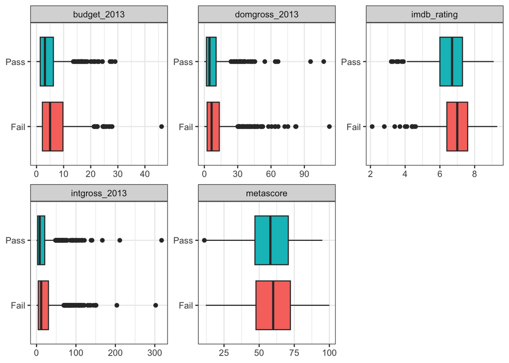

```r
bechdel %>%
  select(test, budget_2013, domgross_2013, intgross_2013, imdb_rating, metascore) %>%

    pivot_longer(cols = 2:6,
               names_to = "feature",
               values_to = "value") %>%
  ggplot()+
  aes(x=test, y = value, fill = test)+
  coord_flip()+
  geom_boxplot()+
  facet_wrap(~feature, scales = "free")+
  theme_bw()+
  theme(legend.position = "none")+
  labs(x=NULL,y = NULL)
```

## 2.3 Scatterplot - Correlation Matrix

Write a paragraph discussing the output of the following

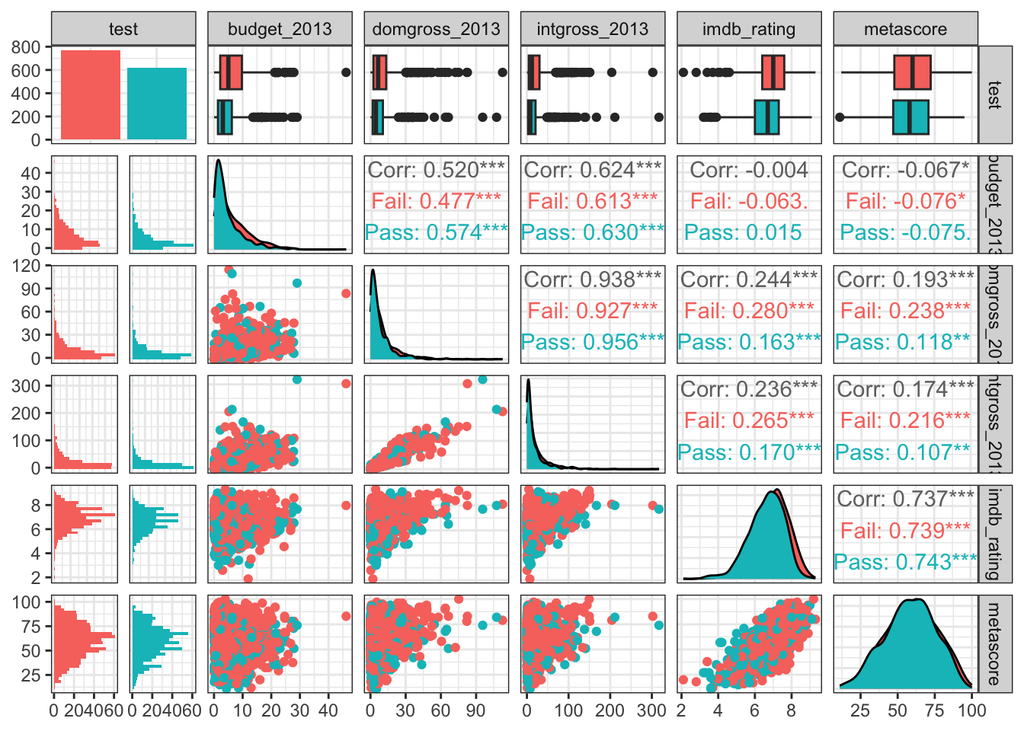

```r
bechdel %>%
  select(test, budget_2013, domgross_2013, intgross_2013, imdb_rating, metascore)%>%
  ggpairs(aes(colour=test), alpha=0.2)+
  theme_bw()
```

## 2.4 Categorical variables

Write a paragraph discussing the output of the following

```r
bechdel %>%
  group_by(genre, test) %>%
  summarise(n = n()) %>%
  mutate(prop = n/sum(n))
```

```
## # A tibble: 24 × 4
## # Groups:   genre [14]
##    genre     test      n  prop
##    <chr>     <fct> <int> <dbl>
##  1 Action    Fail    260 0.707
##  2 Action    Pass    108 0.293
##  3 Adventure Fail     52 0.559
##  4 Adventure Pass     41 0.441
##  5 Animation Fail     63 0.677
##  6 Animation Pass     30 0.323
##  7 Biography Fail     36 0.554
##  8 Biography Pass     29 0.446
##  9 Comedy    Fail    138 0.427
## 10 Comedy    Pass    185 0.573
## # ℹ 14 more rows
```

```r
bechdel %>%
  group_by(rated, test) %>%
  summarise(n = n()) %>%
  mutate(prop = n/sum(n))
```

```
## # A tibble: 10 × 4
## # Groups:   rated [5]
##    rated test      n  prop
##    <chr> <fct> <int> <dbl>
##  1 G     Fail     16 0.615
##  2 G     Pass     10 0.385
##  3 NC-17 Fail      5 0.833
##  4 NC-17 Pass      1 0.167
##  5 PG    Fail    115 0.561
##  6 PG    Pass     90 0.439
##  7 PG-13 Fail    283 0.529
##  8 PG-13 Pass    252 0.471
##  9 R     Fail    353 0.568
## 10 R     Pass    269 0.432
```

# 3 Train first models. `test ~ metascore + imdb_rating`

```r
lr_mod <- logistic_reg() %>%
  set_engine(engine = "glm") %>%
  set_mode("classification")

lr_mod
```

```
## Logistic Regression Model Specification (classification)
##
## Computational engine: glm
```

```r
tree_mod <- decision_tree() %>%
  set_engine(engine = "C5.0") %>%
  set_mode("classification")

tree_mod
```

```
## Decision Tree Model Specification (classification)
##
## Computational engine: C5.0
```

```r
lr_fit <- lr_mod %>% # parsnip model
  fit(test ~ metascore + imdb_rating, # a formula
    data = bechdel_train # dataframe
  )

tree_fit <- tree_mod %>% # parsnip model
  fit(test ~ metascore + imdb_rating, # a formula
    data = bechdel_train # dataframe
  )
```

## 3.1 Logistic regression

```r
lr_fit %>%
  broom::tidy()
```

```
## # A tibble: 3 × 5
##   term        estimate std.error statistic  p.value
##   <chr>          <dbl>     <dbl>     <dbl>    <dbl>
## 1 (Intercept)   2.80     0.494        5.68 1.35e- 8
## 2 metascore     0.0207   0.00536      3.86 1.13e- 4
## 3 imdb_rating  -0.625    0.100       -6.24 4.36e-10
```

```r
lr_preds <- lr_fit %>%
  augment(new_data = bechdel_train) %>%
  mutate(.pred_match = if_else(test == .pred_class, 1, 0))
```

### 3.1.1 Confusion matrix

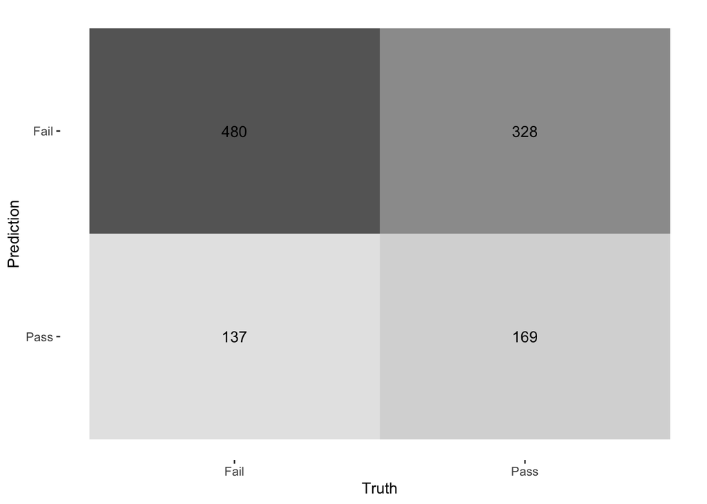

```r
lr_preds %>%
  conf_mat(truth = test, estimate = .pred_class) %>%
  autoplot(type = "heatmap")
```

## 3.2 Decision Tree

```r
tree_preds <- tree_fit %>%
  augment(new_data = bechdel_train) %>%
  mutate(.pred_match = if_else(test == .pred_class, 1, 0))
```

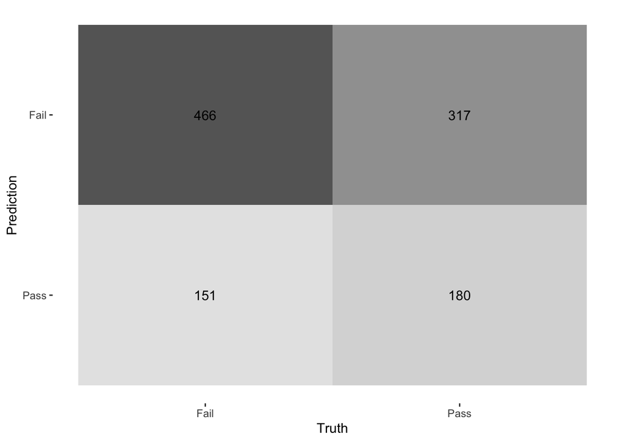

```r
tree_preds %>%
  conf_mat(truth = test, estimate = .pred_class) %>%
  autoplot(type = "heatmap")
```

We have amended the code to use the same training sample

More or less the same, with larger percentage of false positives (14% vs 12% in logistic regression) but lower percentage of false negatives (28% vs 29%)

## 3.3 Draw the decision tree

[figure not shown]

```r
draw_tree <-
    rpart::rpart(
        test ~ metascore + imdb_rating,
        data = bechdel_train, # uses data that contains both birth weight and `low`
        control = rpart::rpart.control(maxdepth = 5, cp = 0, minsplit = 10)
    ) %>%
    partykit::as.party()
plot(draw_tree)
```

# 4 Cross Validation

Run the code below. What does it return?

```r
set.seed(123)
bechdel_folds <- vfold_cv(data = bechdel_train,
                          v = 10,
                          strata = test)
bechdel_folds
```

```
## #  10-fold cross-validation using stratification
## # A tibble: 10 × 2
##    splits             id
##    <list>             <chr>
##  1 <split [1002/112]> Fold01
##  2 <split [1002/112]> Fold02
##  3 <split [1002/112]> Fold03
##  4 <split [1002/112]> Fold04
##  5 <split [1002/112]> Fold05
##  6 <split [1002/112]> Fold06
##  7 <split [1002/112]> Fold07
##  8 <split [1004/110]> Fold08
##  9 <split [1004/110]> Fold09
## 10 <split [1004/110]> Fold10
```

??? It just returns a list of 10 folds (splits) ??? Probably to use it later in a loop

## 4.1 `fit_resamples()`

Trains and tests a resampled model.

```r
lr_fit <- lr_mod %>%
  fit_resamples(
    test ~ metascore + imdb_rating,

    # Instead of data, the argument is resamples - perhaps, to use in a loop?
    resamples = bechdel_folds
  )


tree_fit <- tree_mod %>%
  fit_resamples(
    test ~ metascore + imdb_rating,
    resamples = bechdel_folds
  )
```

## 4.2 `collect_metrics()`

Unnest the metrics column from a tidymodels `fit_resamples()`

```r
collect_metrics(lr_fit)
```

```
## # A tibble: 2 × 6
##   .metric  .estimator  mean     n std_err .config
##   <chr>    <chr>      <dbl> <int>   <dbl> <chr>
## 1 accuracy binary     0.575    10  0.0149 Preprocessor1_Model1
## 2 roc_auc  binary     0.606    10  0.0189 Preprocessor1_Model1
```

```r
collect_metrics(tree_fit)
```

```
## # A tibble: 2 × 6
##   .metric  .estimator  mean     n std_err .config
##   <chr>    <chr>      <dbl> <int>   <dbl> <chr>
## 1 accuracy binary     0.571    10  0.0156 Preprocessor1_Model1
## 2 roc_auc  binary     0.547    10  0.0201 Preprocessor1_Model1
```

```r
tree_preds <- tree_mod %>%
  fit_resamples(
    test ~ metascore + imdb_rating,
    resamples = bechdel_folds,
    control = control_resamples(save_pred = TRUE) #<<
  )

# What does the data for ROC look like?
tree_preds %>%
  collect_predictions() %>%
  roc_curve(truth = test, .pred_Fail)
```

```
## # A tibble: 29 × 3
##    .threshold specificity sensitivity
##         <dbl>       <dbl>       <dbl>
##  1   -Inf         0             1
##  2      0.262     0             1
##  3      0.317     0.00201       0.989
##  4      0.373     0.00805       0.982
##  5      0.440     0.0181        0.976
##  6      0.459     0.0443        0.943
##  7      0.460     0.0765        0.924
##  8      0.464     0.115         0.901
##  9      0.465     0.147         0.887
## 10      0.465     0.191         0.864
## # ℹ 19 more rows
```

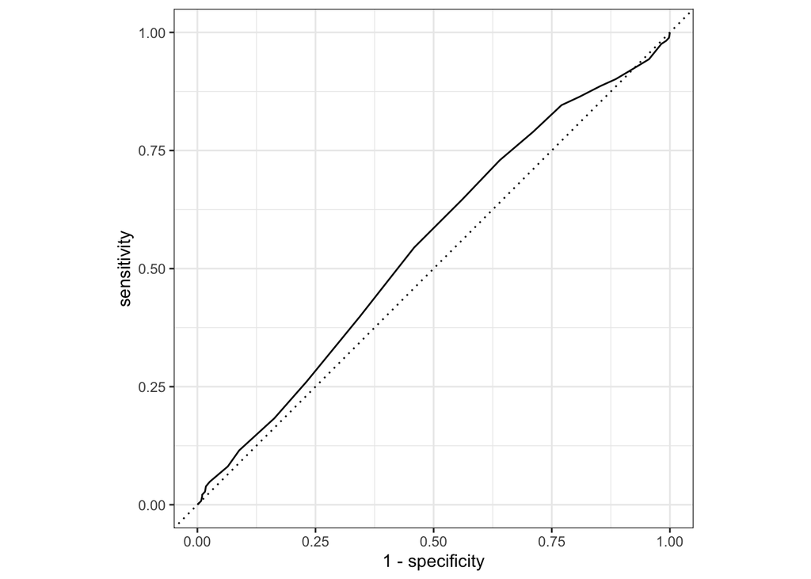

```r
# Draw the ROC
tree_preds %>%
  collect_predictions() %>%
  roc_curve(truth = test, .pred_Fail) %>%
  autoplot()
```

# 5 Build a better training set with `recipes`

## 5.1 Preprocessing options

- Encode categorical predictors
- Center and scale variables
- Handle class imbalance
- Impute missing data
- Perform dimensionality reduction
- … …

## 5.2 To build a recipe

1. Start the `recipe()`
2. Define the variables involved
3. Describe **prep**rocessing [step-by-step]

## 5.3 Collapse Some Categorical Levels

Do we have any `genre` with few observations? Assign genres that have less than 3% to a new category ‘Other’

[figure not shown]

```r
movie_rec <-
  recipe(test ~ .,
         data = bechdel_train) %>%

  # Genres with less than 5% will be in a catewgory 'Other'
    step_other(genre, threshold = .03)
```

## 5.4 Before recipe

```
## # A tibble: 14 × 2
##    genre           n
##    <chr>       <int>
##  1 Action        293
##  2 Comedy        254
##  3 Drama         213
##  4 Adventure      75
##  5 Animation      72
##  6 Crime          68
##  7 Horror         68
##  8 Biography      50
##  9 Mystery         7
## 10 Fantasy         5
## 11 Sci-Fi          3
## 12 Thriller        3
## 13 Documentary     2
## 14 Musical         1
```

## 5.5 After recipe

```r
movie_rec %>%
  prep() %>%
  bake(new_data = bechdel_train) %>%
  count(genre, sort = TRUE)
```

```
## # A tibble: 9 × 2
##   genre         n
##   <fct>     <int>
## 1 Action      293
## 2 Comedy      254
## 3 Drama       213
## 4 Adventure    75
## 5 Animation    72
## 6 Crime        68
## 7 Horror       68
## 8 Biography    50
## 9 other        21
```

## 5.6 `step_dummy()`

Converts nominal data into numeric dummy variables

```r
movie_rec <- recipe(test ~ ., data = bechdel) %>%
  step_other(genre, threshold = .03) %>%
  step_dummy(all_nominal_predictors())

movie_rec
```

```
## ── Recipe ──────────────────────────────────────────────────────────────────────
```

```
## ── Inputs
```

```
## Number of variables by role
```

```
## outcome:   1
## predictor: 9
```

```
## ── Operations
```

```
## • Collapsing factor levels for: genre
```

```
## • Dummy variables from: all_nominal_predictors()
```

## 5.7 Let’s think about the modelling

What if there were no films with `rated` NC-17 in the training data?

- Will the model have a coefficient for `rated` NC-17?
- What will happen if the test data includes a film with `rated` NC-17?

The model will have no coefficient, because the dummy variable for the NC-17 would not be created in the first place. Subsequently, if test data includes such observations, two things could happen:

- The model breaks down as it does not know how to interpret new value of the variable (or it splits new variables in a list of dummys with 1 extra compared to the testing sample)
- The model just ignores the unknown value, applying 0 to all dummies and in fact using the implied coefficient for the base value (say, rating “G”). However, actual category (“NC-17”) is different, which would distort prediction capabilities.

## 5.8 `step_novel()`

Adds a catch-all level to a factor for any new values not encountered in model training, which lets R intelligently predict new levels in the test set.

```r
movie_rec <- recipe(test ~ ., data = bechdel) %>%
  step_other(genre, threshold = .03) %>%
  step_novel(all_nominal_predictors) %>% # Use *before* `step_dummy()` so new level is dummified
  step_dummy(all_nominal_predictors())
```

## 5.9 `step_zv()`

Intelligently handles zero variance variables (variables that contain only a single value)

```r
movie_rec <- recipe(test ~ ., data = bechdel) %>%
  step_other(genre, threshold = .03) %>%
  step_novel(all_nominal(), -all_outcomes()) %>% # Use *before* `step_dummy()` so new level is dummified
  step_dummy(all_nominal(), -all_outcomes()) %>%
  step_zv(all_numeric(), -all_outcomes())
```